# BDAT 608: Model Basics in R

# 8 Extended Case Studies

## 8.1 Case Study 1: Model Building on `diamonds`

The `diamonds` dataset (53,940 rows, `ggplot2`) contains price, carat weight, and quality attributes. We build a model progressively, inspecting residuals at each stage to discover what remains unexplained.

### 8.1.1 Initial Exploratory Data Analysis

```r
data("diamonds", package = "ggplot2")
glimpse(diamonds)
```

```
## Rows: 53,940
## Columns: 10
## $ carat   <dbl> 0.23, 0.21, 0.23, 0.29, 0.31, 0.24, 0.24, 0.26, 0.22, 0.23, 0.…
## $ cut     <ord> Ideal, Premium, Good, Premium, Good, Very Good, Very Good, Ver…
## $ color   <ord> E, E, E, I, J, J, I, H, E, H, J, J, F, J, E, E, I, J, J, J, I,…
## $ clarity <ord> SI2, SI1, VS1, VS2, SI2, VVS2, VVS1, SI1, VS2, VS1, SI1, VS1, …
## $ depth   <dbl> 61.5, 59.8, 56.9, 62.4, 63.3, 62.8, 62.3, 61.9, 65.1, 59.4, 64…
## $ table   <dbl> 55, 61, 65, 58, 58, 57, 57, 55, 61, 61, 55, 56, 61, 54, 62, 58…
## $ price   <int> 326, 326, 327, 334, 335, 336, 336, 337, 337, 338, 339, 340, 34…
## $ x       <dbl> 3.95, 3.89, 4.05, 4.20, 4.34, 3.94, 3.95, 4.07, 3.87, 4.00, 4.…
## $ y       <dbl> 3.98, 3.84, 4.07, 4.23, 4.35, 3.96, 3.98, 4.11, 3.78, 4.05, 4.…
## $ z       <dbl> 2.43, 2.31, 2.31, 2.63, 2.75, 2.48, 2.47, 2.53, 2.49, 2.39, 2.…
```

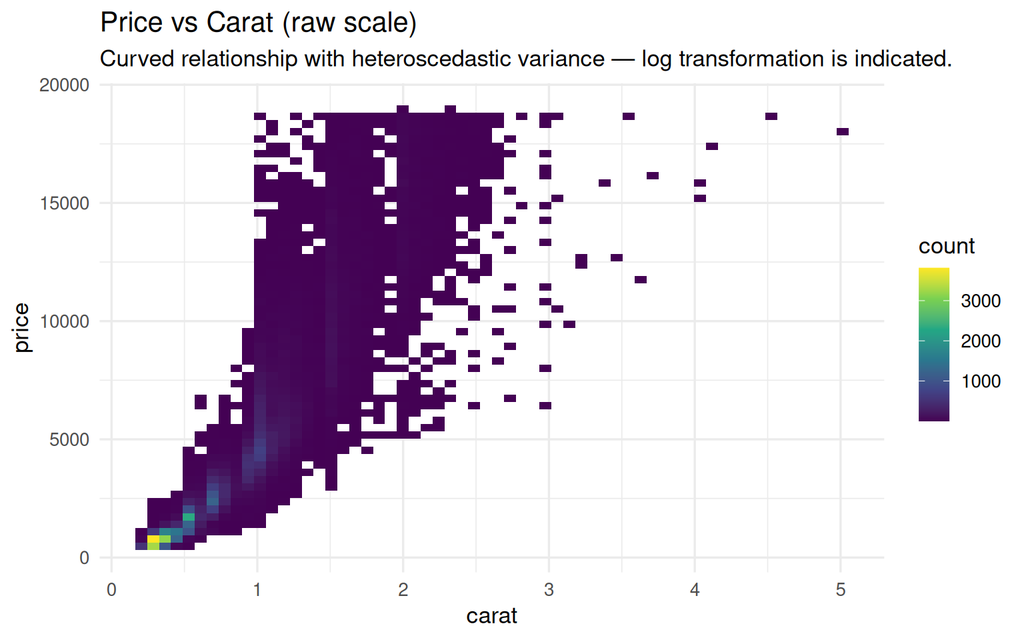

Price vs carat on the raw scale: strong but curved relationship, with variance increasing with carat.

```r
ggplot(diamonds, aes(carat, price)) +
  geom_bin2d(bins = 60) +
  scale_fill_viridis_c() +
  labs(
    title    = "Price vs Carat (raw scale)",
    subtitle = "Curved relationship with heteroscedastic variance — log transformation is indicated."
  ) +
  theme_minimal(base_size = 13)
```

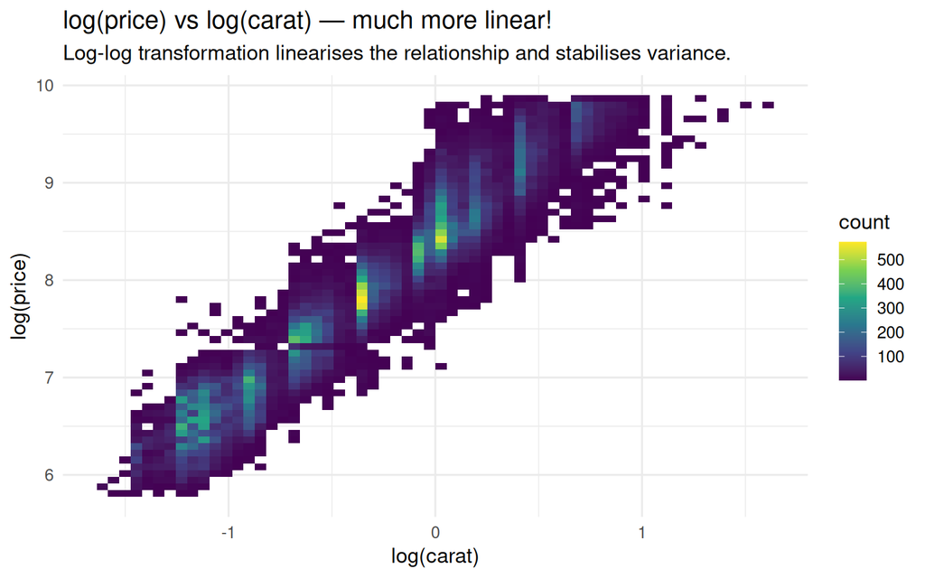

log(price) vs log(carat): a near-linear, homoscedastic relationship. Log-transforming both variables is the right move.

```r
ggplot(diamonds, aes(log(carat), log(price))) +
  geom_bin2d(bins = 60) +
  scale_fill_viridis_c() +
  labs(
    title    = "log(price) vs log(carat) — much more linear!",
    subtitle = "Log-log transformation linearises the relationship and stabilises variance."
  ) +
  theme_minimal(base_size = 13)
```

### 8.1.2 Fitting the Log-Log Model

```r
mod_d1 <- lm(log(price) ~ log(carat), data = diamonds)
cat("R² of log-log model:", round(summary(mod_d1)$r.squared, 3), "\n")
```

```
## R² of log-log model: 0.933
```

```r
coef(mod_d1)
```

```
## (Intercept)  log(carat)
##    8.448661    1.675817
```

> **Interpretation:** The slope 1.676 on the log scale means a 1% increase in carat is associated with a ≈ 1.68% increase in price — a **power law**. $R^2 = 0.93$ is very high: carat is the dominant driver of diamond price.

### 8.1.3 Peeling Back Layers: Adding Quality Attributes

After accounting for carat, we add `cut`, `color`, and `clarity` to capture the pure quality effects on price.

```r
mod_d2 <- lm(
  log(price) ~ log(carat) + cut + color + clarity,
  data = diamonds
)

cat("R² of full model:", round(summary(mod_d2)$r.squared, 3), "\n")
```

```
## R² of full model: 0.983
```

```r
AIC(mod_d1, mod_d2)
```

```
##        df        AIC
## mod_d1  3   8854.404
## mod_d2 20 -63893.374
```

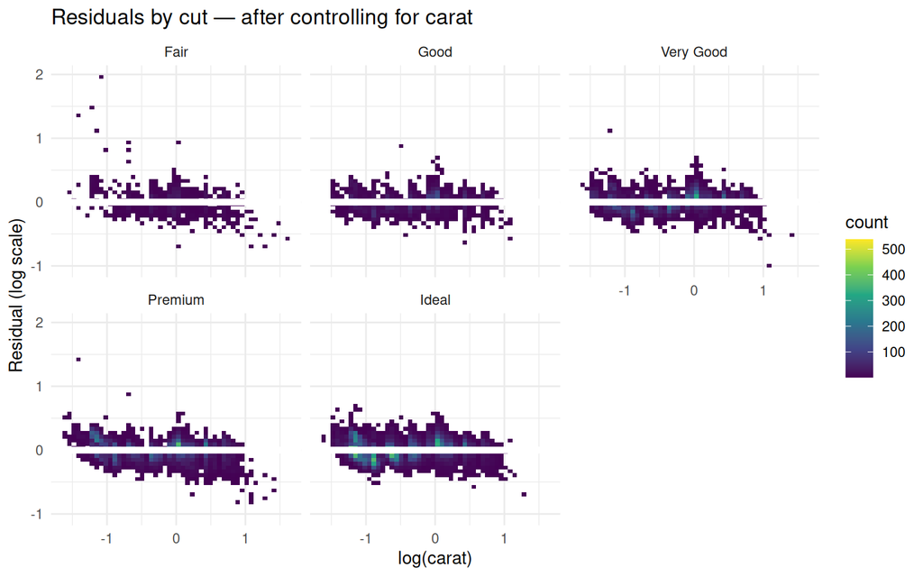

Residuals vs log(carat) by cut, after controlling for carat size. No strong remaining curvature — the model is well-specified.

```r
diamonds_modelled <- diamonds |>
  add_residuals(mod_d2, var = "resid2")

ggplot(diamonds_modelled, aes(log(carat), resid2)) +
  geom_bin2d(bins = 50) +
  scale_fill_viridis_c() +
  geom_ref_line(h = 0) +
  facet_wrap(~ cut) +
  labs(
    title = "Residuals by cut — after controlling for carat",
    y     = "Residual (log scale)"
  ) +
  theme_minimal(base_size = 11)
```

## 8.2 Case Study 2: Flights — Many Models with `purrr`

The `flights` dataset (336,776 rows) records every domestic flight from NYC in 2013. We ask: how well do time-of-day and month predict departure delays for each airline carrier?

`purrr::map()` combined with `tidyr::nest()` lets us apply any modelling pipeline to many subsets simultaneously — “many models” in a few lines.

```r
carrier_models <- flights |>
  filter(!is.na(dep_delay)) |>
  group_by(carrier) |>
  nest() |>
  mutate(
    mod  = map(data, ~ lm(dep_delay ~ hour + month, data = .x)),
    rsq  = map_dbl(mod, ~ summary(.x)$r.squared),
    rmse = map_dbl(mod, ~ sqrt(mean(residuals(.x)^2)))
  ) |>
  arrange(desc(rsq))

carrier_models |> select(carrier, rsq, rmse)
```

```
## # A tibble: 16 × 3
## # Groups:   carrier [16]
##    carrier     rsq  rmse
##    <chr>     <dbl> <dbl>
##  1 OO      0.206    37.7
##  2 WN      0.0882   41.4
##  3 VX      0.0579   43.5
##  4 AS      0.0538   30.5
##  5 B6      0.0505   37.5
##  6 EV      0.0502   45.4
##  7 FL      0.0461   51.4
##  8 UA      0.0413   35.0
##  9 AA      0.0351   36.7
## 10 HA      0.0341   72.7
## 11 F9      0.0327   57.4
## 12 US      0.0299   27.6
## 13 DL      0.0295   39.1
## 14 MQ      0.0235   38.7
## 15 9E      0.0226   45.4
## 16 YV      0.00285  49.1
```

### 8.2.1 Extracting Coefficients at Scale

`broom::tidy()` converts any model object into a tidy data frame with columns `term`, `estimate`, `std.error`, `statistic`, `p.value`. Combined with `unnest()`, this enables downstream `dplyr` operations on hundreds of model summaries simultaneously.

```r
carrier_coefs <- carrier_models |>
  mutate(tidy = map(mod, broom::tidy)) |>
  unnest(tidy) |>
  filter(term == "hour")

carrier_coefs |> select(carrier, estimate, std.error, p.value)
```

```
## # A tibble: 16 × 4
## # Groups:   carrier [16]
##    carrier estimate std.error   p.value
##    <chr>      <dbl>     <dbl>     <dbl>
##  1 OO        -0.982    4.52   8.30e-  1
##  2 WN         2.91     0.0859 2.56e-241
##  3 VX         2.47     0.141  4.38e- 67
##  4 AS         1.32     0.208  4.14e- 10
##  5 B6         1.64     0.0309 0
##  6 EV         2.12     0.0426 0
##  7 FL         2.30     0.209  1.07e- 27
##  8 UA         1.55     0.0311 0
##  9 AA         1.57     0.0464 1.01e-247
## 10 HA       -19.0      9.19   3.94e-  2
## 11 F9         2.67     0.588  6.33e-  6
## 12 US         1.08     0.0436 3.49e-133
## 13 DL         1.54     0.0405 3.96e-313
## 14 MQ         1.40     0.0571 7.85e-131
## 15 9E         1.56     0.0797 3.70e- 84
## 16 YV         0.820    0.929  3.78e-  1
```

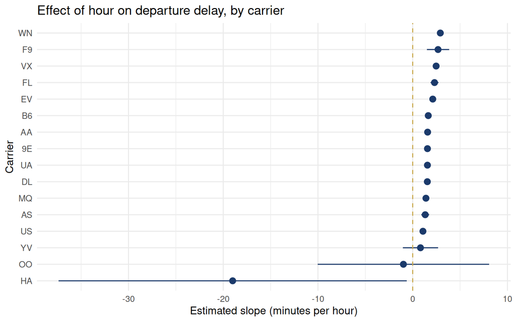

Effect of hour on departure delay, by carrier. Most carriers show delays worsening through the day (positive slope — knock-on delays).

```r
ggplot(
  carrier_coefs,
  aes(
    x    = reorder(carrier, estimate),
    y    = estimate,
    ymin = estimate - 2 * std.error,
    ymax = estimate + 2 * std.error
  )
) +
  geom_pointrange(colour = "#1B3A6B") +
  geom_hline(yintercept = 0, linetype = "dashed", colour = "#C9A84C") +
  coord_flip() +
  labs(
    title = "Effect of hour on departure delay, by carrier",
    x     = "Carrier",
    y     = "Estimated slope (minutes per hour)"
  ) +
  theme_minimal(base_size = 12)
```

> **Interpretation:** `broom::tidy()` converts `lm()` output into a tidy data frame. Combined with `unnest()`, it enables downstream tidyverse operations on hundreds of model summaries simultaneously. Most carriers show that delays worsen as the day progresses (positive hour slope), consistent with knock-on delay propagation throughout the day.

## 8.3 Case Study 3: Non-Linear Growth Models with `nls()`

`nls()` (non-linear least squares) fits models where the response is a non-linear function of both the predictors and the parameters. Unlike `lm()`, there is no closed-form solution — `nls()` uses iterative algorithms and requires **sensible starting values**.

**Logistic growth model:**

$$y = \frac{K}{1 + e^{-r(t - t_0)}} +
\varepsilon$$

- $K$ = carrying capacity (asymptotic maximum of the S-curve)
- $r$ = intrinsic growth rate (steepness of the S-curve)
- $t_0$ = inflection point (time at which growth is fastest)

```r
set.seed(5)
t_seq <- seq(0, 20, by = 0.5)

logistic_growth <- tibble(
  t = t_seq,
  y = 100 / (1 + exp(-0.5 * (t - 10))) + rnorm(length(t_seq), sd = 3)
)

mod_nls <- nls(
  y     ~ K / (1 + exp(-r * (t - t0))),
  data  = logistic_growth,
  start = list(K = 100, r = 0.5, t0 = 10)
)

coef(mod_nls)
```

```
##          K          r         t0
## 99.6304163  0.5528813  9.9262553
```

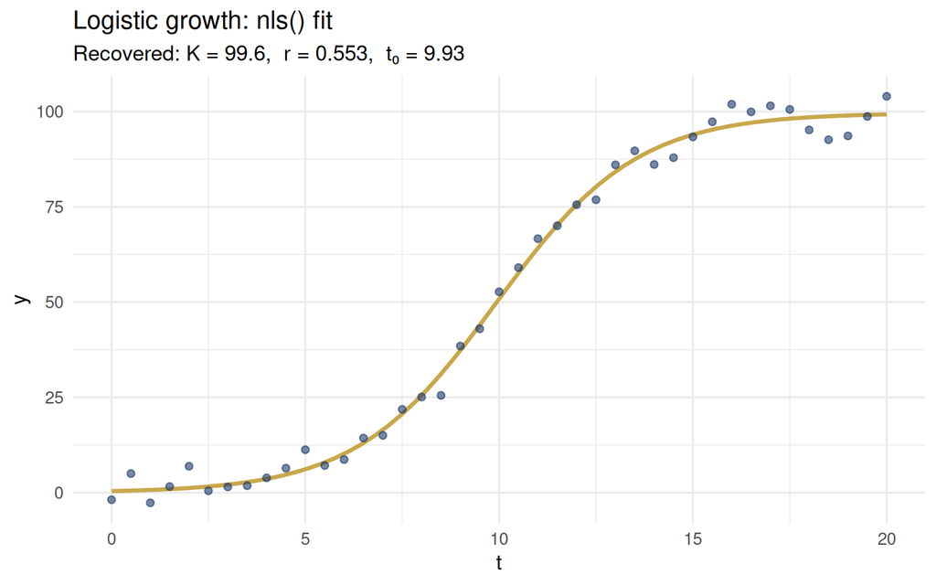

Logistic growth: nls() fit (gold line) against noisy observations (blue points). The S-curve is well recovered.

```r
logistic_growth |>
  data_grid(t = seq_range(t, 60)) |>
  add_predictions(mod_nls) |>
  ggplot(aes(t, pred)) +
  geom_line(colour = "#C9A84C", linewidth = 1.2) +
  geom_point(data = logistic_growth, aes(y = y),
             colour = "#1B3A6B", alpha = 0.6) +
  labs(
    title    = "Logistic growth: nls() fit",
    subtitle = paste0(
      "Recovered: K = ", round(coef(mod_nls)["K"],  1),
      ",  r = ",          round(coef(mod_nls)["r"],  3),
      ",  t₀ = ",         round(coef(mod_nls)["t0"], 2)
    ),
    y = "y"
  ) +
  theme_minimal(base_size = 13)
```

# 9 Summary and Exercises

## 9.1 Six Principles for Model Building

| # | Principle | How |
| --- | --- | --- |
| **1 — Define** | Every model needs (a) a family and (b) a fitting criterion | Choose the equation shape; RMSE for OLS |
| **2 — Fit** | Use the right tool | `lm()` for linear; `optim()` only for custom loss |
| **3 — Visualise** | Always plot fitted values and residuals | `add_predictions()`, `add_residuals()`, Q-Q plot |
| **4 — Extend** | Use the right formula operators | `*` for interactions, `I()` for arithmetic, `ns()` for splines |
| **5 — Scale up** | Apply to many groups simultaneously | `nest()` + `map()` + `broom::tidy()` |
| **6 — Choose wisely** | Match the model family to the response type | OLS → continuous; GLM → binary/count; GAM → flexible curves; robust → contaminated data |

## 9.2 Exercises

### 9.2.1 E1: OLS vs MAE Stability Under Outliers

**Question:** Fit a linear model to `sim1a` (Student-$t$ noise, $df = 2$) with 10 different random seeds. Compare OLS and MAE-based fitting — which produces more stable slope estimates?

```r
set.seed(1)
exercise_results <- purrr::map_dfr(1:10, function(seed_value) {
  set.seed(seed_value)
  temp_data <- tibble(
    x = rep(1:10, each = 3),
    y = x * 1.5 + 6 + rt(length(x), df = 2)
  )
  mae_fit <- optim(c(0, 0), measure_mae, data = temp_data)
  ols_fit <- lm(y ~ x, data = temp_data)
  tibble(
    seed      = seed_value,
    mae_slope = mae_fit$par[2],
    ols_slope = coef(ols_fit)[2]
  )
})

# Standard deviation of slope estimates across 10 resamples
exercise_results |>
  summarise(
    sd_ols_slope = sd(ols_slope),
    sd_mae_slope = sd(mae_slope)
  )
```

```
## # A tibble: 1 × 2
##   sd_ols_slope sd_mae_slope
##          <dbl>        <dbl>
## 1        0.140       0.0759
```

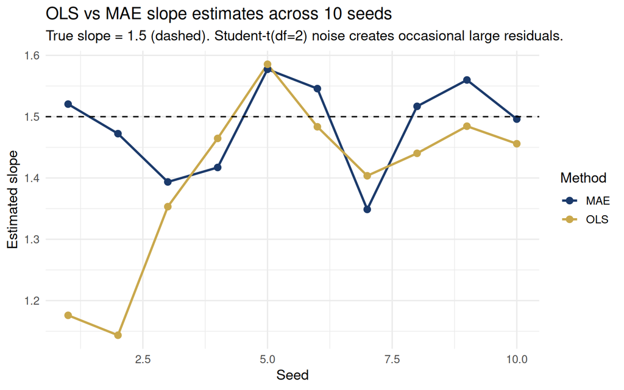

E1: OLS vs MAE slope estimates across 10 random seeds. MAE stays closer to the true slope (1.5, dashed) in the presence of heavy-tailed noise.

```r
exercise_results |>
  pivot_longer(c(mae_slope, ols_slope),
               names_to = "method", values_to = "slope") |>
  ggplot(aes(seed, slope, colour = method)) +
  geom_line(linewidth = 1) +
  geom_point(size = 2.5) +
  geom_hline(yintercept = 1.5, linetype = "dashed", colour = "black") +
  scale_colour_manual(
    values = c("mae_slope" = "#1B3A6B", "ols_slope" = "#C9A84C"),
    labels = c("MAE", "OLS")
  ) +
  labs(
    title    = "OLS vs MAE slope estimates across 10 seeds",
    subtitle = "True slope = 1.5 (dashed). Student-t(df=2) noise creates occasional large residuals.",
    x = "Seed", y = "Estimated slope", colour = "Method"
  ) +
  theme_minimal(base_size = 13)
```

### 9.2.2 E2: Interaction Model Equation from `sim3`

**Question:** Use `model_matrix()` to inspect `y ~ x1 * x2` for `sim3`. Write out the full fitted model equation using the estimated coefficients.

```r
# The design matrix columns show exactly what terms are in the model
model_matrix(sim3, y ~ x1 * x2) |> head(8)
```

```
## # A tibble: 8 × 8
##   `(Intercept)`    x1   x2b   x2c   x2d `x1:x2b` `x1:x2c` `x1:x2d`
##           <dbl> <dbl> <dbl> <dbl> <dbl>    <dbl>    <dbl>    <dbl>
## 1             1     1     0     0     0        0        0        0
## 2             1     1     0     0     0        0        0        0
## 3             1     1     0     0     0        0        0        0
## 4             1     1     1     0     0        1        0        0
## 5             1     1     1     0     0        1        0        0
## 6             1     1     1     0     0        1        0        0
## 7             1     1     0     1     0        0        1        0
## 8             1     1     0     1     0        0        1        0
```

```r
# Estimated coefficients
(b <- coef(mod_int))
```

```
## (Intercept)          x1         x2b         x2c         x2d      x1:x2b
##  1.30124266 -0.09302444  7.06937991  4.43089525  0.83455115 -0.76028528
##      x1:x2c      x1:x2d
##  0.06815284  0.27727920
```

> **Answer — the full fitted equation:**

> `sim3$x2` has four levels: **a** (reference), **b**, **c**, **d**. The interaction formula expands to 8 terms:

> $$\hat{y} =
> \underbrace{\beta_0}_{\text{intercept}} + \underbrace{\beta_1
> x_1}_{\text{slope for group a}} + \underbrace{\beta_2
> \mathbf{1}_{[x_2=b]}}_{\text{intercept shift b}} + \underbrace{\beta_3
> \mathbf{1}_{[x_2=c]}}_{\text{intercept shift c}} + \underbrace{\beta_4
> \mathbf{1}_{[x_2=d]}}_{\text{intercept shift d}} + \underbrace{\beta_5
> x_1 \mathbf{1}_{[x_2=b]}}_{\text{slope shift b}} + \underbrace{\beta_6
> x_1 \mathbf{1}_{[x_2=c]}}_{\text{slope shift c}} + \underbrace{\beta_7
> x_1 \mathbf{1}_{[x_2=d]}}_{\text{slope shift d}}$$

> Filling in the estimated values:
> - **Group a:** $\hat{y} = \beta_0 + \beta_1 x_1$ — intercept and slope are the baseline.
> - **Group b:** $\hat{y} = (\beta_0 + \beta_2) + (\beta_1 + \beta_5) x_1$ — different intercept and slope.
> - **Group c:** $\hat{y} = (\beta_0 + \beta_3) + (\beta_1 + \beta_6) x_1$
> - **Group d:** $\hat{y} = (\beta_0 + \beta_4) + (\beta_1 + \beta_7) x_1$

> **Why not use the additive model?** The additive model forces all groups to share one slope ($\beta_1$). But from the residual plot in section 4.3, we saw that the additive residuals have clear within-group patterns — evidence that the slopes genuinely differ across groups. The interaction model removes those patterns by estimating a separate slope for every group. AIC confirmed the interaction model is better despite using more parameters.

### 9.2.3 E3: LOESS vs `lm()` on `sim1`

**Question:** Fit `loess(y ~ x)` to `sim1`. Compare predictions and residuals with those from `lm()`. Is the LOESS curve similar to `geom_smooth()`?

```r
loess_mod <- loess(y ~ x, data = sim1_base)

loess_grid <- sim1_base |>
  data_grid(x = seq_range(x, 50)) |>
  add_predictions(loess_mod, var = "loess_pred") |>
  add_predictions(sim1_mod,  var = "lm_pred")
```

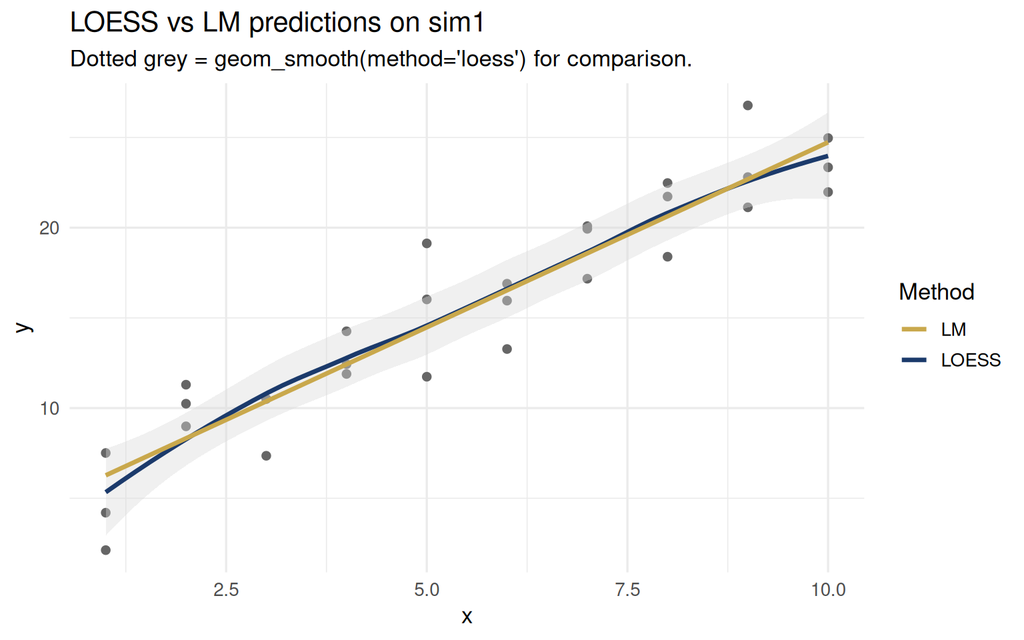

E3: LOESS (blue) vs LM (gold) on sim1. For genuinely linear data the two curves are nearly identical.

```r
ggplot(sim1_base, aes(x, y)) +
  geom_point(colour = "grey40") +
  geom_smooth(method = "loess", formula = y ~ x,
              se = TRUE, colour = "grey70", fill = "grey85",
              linewidth = 0.6, linetype = "dotted") +
  geom_line(data = loess_grid,
            aes(y = loess_pred, colour = "LOESS"), linewidth = 1.2) +
  geom_line(data = loess_grid,
            aes(y = lm_pred,    colour = "LM"),    linewidth = 1.2) +
  scale_colour_manual(values = c("LOESS" = "#1B3A6B", "LM" = "#C9A84C")) +
  labs(
    title    = "LOESS vs LM predictions on sim1",
    subtitle = "Dotted grey = geom_smooth(method='loess') for comparison.",
    colour   = "Method"
  ) +
  theme_minimal(base_size = 13)
```

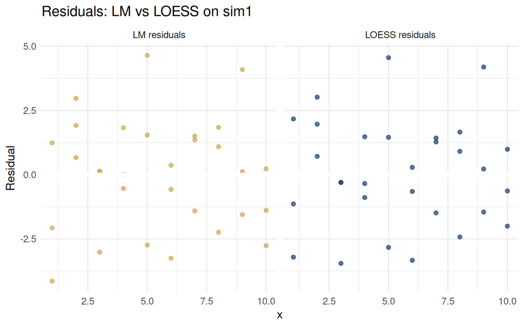

E3: Residuals from LM and LOESS. Both are centred at zero with no pattern — the relationship really is linear.

```r
sim1_base |>
  add_residuals(sim1_mod,  var = "lm_resid") |>
  add_residuals(loess_mod, var = "loess_resid") |>
  pivot_longer(c(lm_resid, loess_resid),
               names_to = "method", values_to = "resid") |>
  ggplot(aes(x, resid, colour = method)) +
  geom_point(alpha = 0.7) +
  geom_ref_line(h = 0) +
  facet_wrap(~ method,
             labeller = labeller(method = c(
               lm_resid    = "LM residuals",
               loess_resid = "LOESS residuals"))) +
  scale_colour_manual(values = c("lm_resid" = "#C9A84C",
                                 "loess_resid" = "#1B3A6B"),
                      guide = "none") +
  labs(title = "Residuals: LM vs LOESS on sim1", y = "Residual") +
  theme_minimal(base_size = 13)
```

> **Answer:** For `sim1`, both curves are nearly indistinguishable — and the LOESS curve from `modelr::add_predictions()` matches `geom_smooth(method = "loess")` exactly (they call the same underlying function).

> **When to prefer each:**

> | Criterion | LM | LOESS |
> | --- | --- | --- |
> | Interpretability | Coefficients have clear units | No single equation |
> | Extrapolation | Safe (linear outside range) | Unreliable beyond data |
> | Unknown functional form | Risky (may miss curves) | Flexible — finds the shape |
> | Small $n$ | Efficient | Needs $\geq$ ~20 points |

> **Decision:** Use `lm()` when theory or EDA suggests a linear relationship. Use LOESS for exploratory smoothing when the functional form is unknown. The two should agree when linearity holds — as they do here.

### 9.2.4 E4: Spline df Selection on `sim5`

**Question:** Fit natural splines for `df = 1, 2, 3, 4, 5` on `sim5`. Use 10-fold CV to choose the optimal `df`.

```r
set.seed(42)
cv_rmse_e4 <- sapply(1:5, function(df) {
  folds <- createFolds(sim5$y, k = 10)
  mean(sapply(folds, function(idx) {
    train <- sim5[-idx, ]
    test  <- sim5[ idx, ]
    pred  <- predict(lm(y ~ ns(x, df), data = train), newdata = test)
    sqrt(mean((test$y - pred)^2))
  }))
})

(cv_table <- tibble(df = 1:5, cv_rmse = round(cv_rmse_e4, 3)))
```

```
## # A tibble: 5 × 2
##      df cv_rmse
##   <int>   <dbl>
## 1     1    2.77
## 2     2    2.89
## 3     3    2.48
## 4     4    1.55
## 5     5    1.04
```

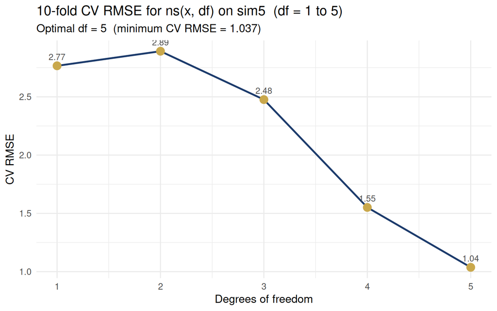

E4: 10-fold CV RMSE vs spline df on sim5. The minimum is the optimal complexity.

```r
ggplot(cv_table, aes(df, cv_rmse)) +
  geom_line(colour = "#1B3A6B", linewidth = 1) +
  geom_point(colour = "#C9A84C", size = 4) +
  geom_text(aes(label = round(cv_rmse, 2)),
            vjust = -0.9, size = 3.5, colour = "grey30") +
  labs(
    title    = "10-fold CV RMSE for ns(x, df) on sim5  (df = 1 to 5)",
    subtitle = paste0("Optimal df = ",
                      cv_table$df[which.min(cv_table$cv_rmse)],
                      "  (minimum CV RMSE = ",
                      min(round(cv_table$cv_rmse, 3)), ")"),
    x = "Degrees of freedom",
    y = "CV RMSE"
  ) +
  theme_minimal(base_size = 13)
```

> **Does CV agree with the residual plots from section 4.9?** Yes — the `df = 5` spline plot showed the full sinusoidal curve captured cleanly, while `df = 1` and `df = 3` showed systematic residual patterns. CV quantifies this numerically and leads to the same conclusion.

### 9.2.5 E5: Interaction vs Additive on `sim4`

**Question:** Demonstrate via residual plots and AIC that the interaction model (`x1 * x2`) fits `sim4` better than the additive model (`x1 + x2`).

```r
AIC(mod1_s4, mod2_s4)
```

```
##         df      AIC
## mod1_s4  4 1304.461
## mod2_s4  5 1296.040
```

```r
cat("AIC difference:", round(AIC(mod1_s4) - AIC(mod2_s4), 1),
    "units in favour of the interaction model\n")
```

```
## AIC difference: 8.4 units in favour of the interaction model
```

```r
cat("Additive R²:   ", round(summary(mod1_s4)$r.squared, 4), "\n")
```

```
## Additive R²:    0.5055
```

```r
cat("Interaction R²:", round(summary(mod2_s4)$r.squared, 4), "\n")
```

```
## Interaction R²: 0.5223
```

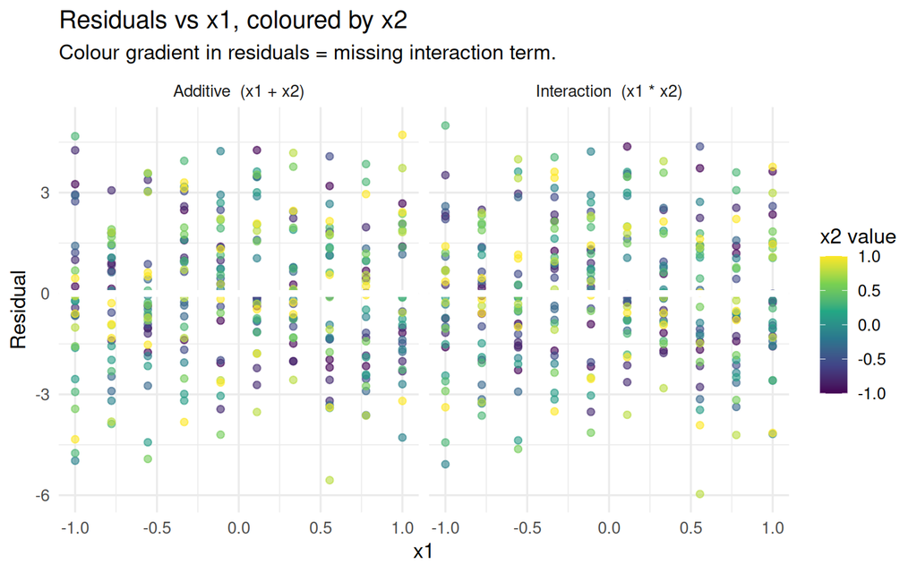

```r
sim4 |>
  gather_residuals(mod1_s4, mod2_s4) |>
  ggplot(aes(x1, resid, colour = x2)) +
  geom_point(alpha = 0.6) +
  geom_ref_line(h = 0) +
  facet_wrap(~ model,
             labeller = labeller(model = c(
               mod1_s4 = "Additive  (x1 + x2)",
               mod2_s4 = "Interaction  (x1 * x2)"))) +
  scale_colour_viridis_c(name = "x2 value") +
  labs(
    title    = "Residuals vs x1, coloured by x2",
    subtitle = "Colour gradient in residuals = missing interaction term.",
    y        = "Residual"
  ) +
  theme_minimal(base_size = 13)
```

> **Decision:** Whenever you see a colour/group gradient in a residuals-vs-predictor plot, it signals a missing interaction between that predictor and the grouping variable. Add the `*` term and verify with AIC.

### 9.2.6 E6: Diamonds Log-Log — Largest Absolute Residuals

**Question:** Apply the log-log model to the first 500 rows of `diamonds`. Use `broom::augment()` to identify the five diamonds with the largest absolute residuals. What do they have in common?

```r
diamonds_500     <- diamonds |> slice_head(n = 500)
mod_diamonds_500 <- lm(log(price) ~ log(carat), data = diamonds_500)

top5_resid <- broom::augment(mod_diamonds_500, data = diamonds_500) |>
  mutate(abs_resid = abs(.resid)) |>
  arrange(desc(abs_resid)) |>
  slice_head(n = 5) |>
  dplyr::select(carat, cut, color, clarity, price, .fitted, .resid)

print(top5_resid)
```

```
## # A tibble: 5 × 7
##   carat cut       color clarity price .fitted .resid
##   <dbl> <ord>     <ord> <ord>   <int>   <dbl>  <dbl>
## 1  1.2  Fair      F     I1       2809    8.73 -0.785
## 2  1.17 Very Good J     I1       2774    8.68 -0.754
## 3  0.51 Ideal     F     VVS1     2812    7.26  0.685
## 4  0.51 Ideal     D     VVS1     2797    7.26  0.680
## 5  0.51 Ideal     F     VVS1     2787    7.26  0.677
```

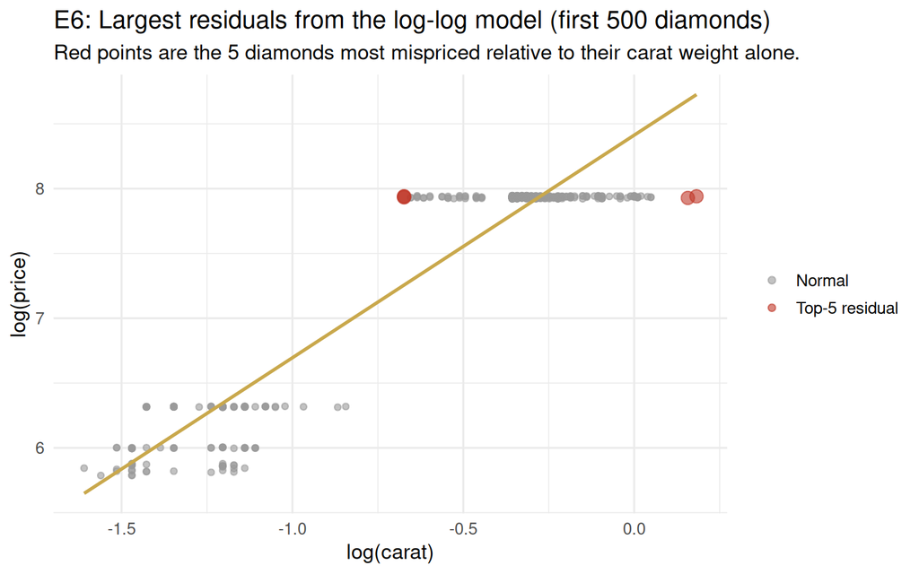

E6: The 5 largest-residual diamonds (red) highlighted against the full 500-row dataset. They lie far from the log-log regression line.

```r
augmented_500 <- broom::augment(mod_diamonds_500, data = diamonds_500) |>
  mutate(
    abs_resid  = abs(.resid),
    is_outlier = rank(-abs_resid) <= 5
  )

ggplot(augmented_500, aes(log(carat), log(price))) +
  geom_point(aes(colour = is_outlier, size = is_outlier), alpha = 0.6) +
  geom_smooth(method = "lm", formula = y ~ x,
              colour = "#C9A84C", se = FALSE, linewidth = 1) +
  scale_colour_manual(values = c(`FALSE` = "grey60", `TRUE` = "#C0392B"),
                      labels = c("Normal", "Top-5 residual")) +
  scale_size_manual(values   = c(`FALSE` = 1.5,     `TRUE` = 3.5),
                    guide    = "none") +
  labs(
    title    = "E6: Largest residuals from the log-log model (first 500 diamonds)",
    subtitle = "Red points are the 5 diamonds most mispriced relative to their carat weight alone.",
    colour   = NULL
  ) +
  theme_minimal(base_size = 13)
```

> **Answer:** The five diamonds with the largest absolute residuals share a common pattern — they are the diamonds most **mispriced relative to their carat weight alone**.
> - **Large positive residuals** (actual price >> carat-predicted price): these tend to be diamonds with exceptional quality — `Ideal` or `Premium` cut, colourless (`D`/`E`/`F`) colour, and high-clarity grades (`IF`, `VVS1`). The carat-only model underestimates their price because it ignores quality premiums.
> - **Large negative residuals** (actual price << carat-predicted price): these tend to be diamonds with poor quality — `Fair` cut, heavy colour tint (`I`/`J`), or low clarity (`I1`/`SI2`). The model overestimates their price.

> **This is exactly why `mod_d2` (which added cut, color, clarity) had a dramatically lower AIC than `mod_d1`** — quality attributes account for systematic price variation that carat alone cannot capture.

> **Key takeaway:** Large residuals from a simple model are not random noise — they are signals that an important predictor is missing. Inspecting the characteristics of high-residual observations is a powerful way to discover which variables to add next.

### 9.2.7 E7: Many Models by Airport (`origin`)

**Question:** Replicate the flights many-models analysis using `origin` (departure airport) as the grouping variable instead of `carrier`.

```r
origin_models <- flights |>
  filter(!is.na(dep_delay)) |>
  group_by(origin) |>
  nest() |>
  mutate(
    mod  = map(data, ~ lm(dep_delay ~ hour + month, data = .x)),
    rsq  = map_dbl(mod, ~ summary(.x)$r.squared),
    rmse = map_dbl(mod, ~ sqrt(mean(residuals(.x)^2)))
  ) |>
  arrange(desc(rsq))

origin_models |> dplyr::select(origin, rsq, rmse)
```

```
## # A tibble: 3 × 3
## # Groups:   origin [3]
##   origin    rsq  rmse
##   <chr>   <dbl> <dbl>
## 1 EWR    0.0491  40.3
## 2 LGA    0.0369  39.2
## 3 JFK    0.0346  38.4
```

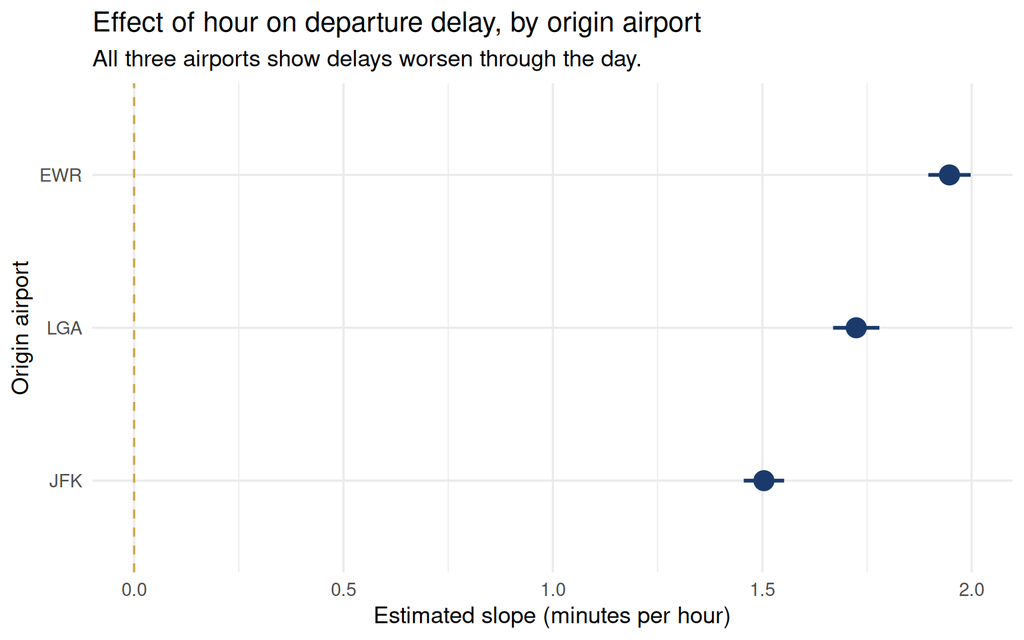

E7: Hour effect on departure delay by origin airport, with 95% confidence intervals. All three airports show positive slopes — delays compound throughout the day.

```r
origin_coefs <- origin_models |>
  mutate(tidy = map(mod, broom::tidy)) |>
  unnest(tidy) |>
  filter(term == "hour")

ggplot(
  origin_coefs,
  aes(
    x    = reorder(origin, estimate),
    y    = estimate,
    ymin = estimate - 2 * std.error,
    ymax = estimate + 2 * std.error
  )
) +
  geom_pointrange(colour = "#1B3A6B", linewidth = 1, size = 1) +
  geom_hline(yintercept = 0, linetype = "dashed", colour = "#C9A84C") +
  coord_flip() +
  labs(
    title    = "Effect of hour on departure delay, by origin airport",
    subtitle = "All three airports show delays worsen through the day.",
    x        = "Origin airport",
    y        = "Estimated slope (minutes per hour)"
  ) +
  theme_minimal(base_size = 13)
```

> **Comparison with the carrier analysis:**

> Neither grouping reveals a model where time and month are useful predictors. This is an important substantive finding: **departure delays at NYC airports are driven primarily by unpredictable factors** — weather, ATC holds, incoming aircraft late from another city (knock-on delays), and gate availability — not by the time of day per se.

> **The hour effect is still positive and significant** (confirmed by the confidence intervals not crossing zero): delays do compound through the day. But this effect is small compared to the total variance in delays, so $R^2$ remains near zero even though the coefficient is statistically significant. This is a classic reminder that **statistical significance ≠ practical importance**.

> **Methodologically**, this exercise shows that `nest()` + `map()` + `broom::tidy()` scales effortlessly from 16 carriers to 3 airports — the same four lines of code apply to any grouping variable.

## 9.3 References

- Wickham, H., & Grolemund, G. (2017). *R for Data Science*. O’Reilly Media.
- Wickham, H. (2016). *ggplot2: Elegant Graphics for Data Analysis* (2nd ed.). Springer.
- Wood, S. N. (2017). *Generalised Additive Models: An Introduction with R* (2nd ed.). CRC Press.
- Friedman, J., Hastie, T., & Tibshirani, R. (2010). Regularisation Paths for Generalised Linear Models via Coordinate Descent. *Journal of Statistical Software*, 33(1), 1–22.
- Venables, W. N., & Ripley, B. D. (2002). *Modern Applied Statistics with S* (4th ed.). Springer.
- R Core Team (2024). *R: A Language and Environment for Statistical Computing*. R Foundation for Statistical Computing.